# 170601_HW14_SIR

Kuei Yueh Ko

2017年6月8日

# set environment

```r
library(dplyr)
library(tidyr)
```

```r
library(ggplot2)
library(gridExtra)
```

# Import and explore data

observed data

```r
datObs <- data.frame(
    Time=c(1, 2, 3.3, 4.3, 5.3, 6.3, 7.3,
           8.3, 9.3, 10.3, 11.3, 12.3, 13.3),
    Obs=c(15.4, 28.03, 41.18, 46.2, 48.23, 50.26,
           51.82,54.27,56.98,58.93,59,60.91,61.83))
```

plot the data

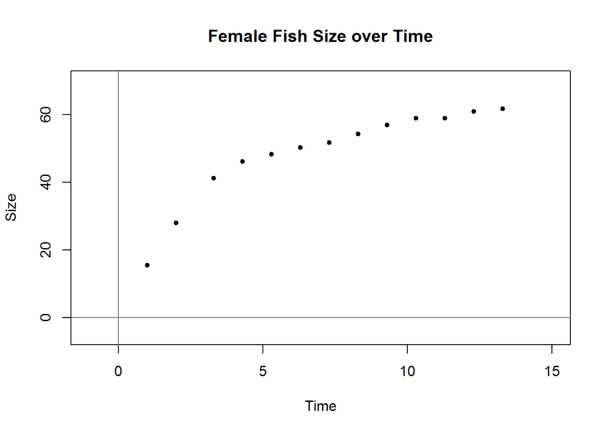

```r
# points
plot(datObs$Time, datObs$Obs,
     main="Female Fish Size over Time",
     xlab="Time",ylab="Size",
     pch=20,
     ylim=c(-5,70),
     xlim=c(-1,15))

# coordinates
abline(v=0,h=0,col="grey50")
```

# von Bertalanffy Growth Model

Here we set population model using exponential function.

VBGF model  
- Linf: the asymptotic average length  
- K: growth rate  
- t0: the time or age when the average length was zero

VBGF model function

```r
# model function
modelVBGF <- function(tt, Linf, K, t0){
    res <- Linf * (1 - exp(-K * (tt-t0)))
    return(res)
} # end func

# get model values
getPred <- function(data, par){
    pred = modelVBGF(
        tt   = data$Time,
        Linf = par[1],
        K    = par[2],
        t0   = par[3])
    return(pred)
} # end func
```

# Likelihood of log-normal distribution

Here we assume the error of values follows the log-normal distribution.

likelihood function for log normal

```r
getLL <- function(obs, pred, sig){
    dev2 <- (log(obs/pred))^2
    res  <- 1/obs *
        (1/sqrt(2*pi*sig*sig)) *
        exp(-dev2/(2*sig*sig))
    return(res)
} # end func getLike2
```

likelihood of the data

```r
getLLDat <- function(data, par){
    # data
    # - Time
    # - Num
    # ==========================
    # prediction
    pred = getPred(data, par)

    # calculate sd
    obs  = data$Obs
    dev2 = (log(obs/pred))^2
    sig  = sqrt(sum(dev2))

    # arrange observed and predicted values
    tmp <- cbind(obs,pred)
    LL <- apply(tmp, 1, function(x){
        getLL(obs=x[1], pred=x[2], sig)
    })
    NLL <- -log(LL)

    # store the results
    Outs <- list()
    Outs$Pred  <- pred
    Outs$Obs   <- obs
    Outs$Dev2  <- dev2
    Outs$Sigma <- sig
    Outs$LL    <- LL
    Outs$NLL   <- NLL
    Outs$T_LL  <- prod(LL)
    Outs$T_NLL <- sum(NLL)
    return(Outs)
} # end
```

object function for optimization

```r
obj_func <- function(data, par, echo=F){
    res <- getLLDat(data, par)
    if (echo){print(c(par,res$T_NLL))}
    return(res$T_NLL)
}
```

Note that There are local minimum in many regions. In this homework we do not need to worry about it which initial values to perform MLE. However, we need to locate a region for parameter space

```r
res <- optim(
    par=c(60, 0.0001, -10),
    obj_func,
    data=datObs,
    echo=T,

    # Linf, K, t0
    lower = c(  1, 0.0001, -0.5),
    upper = c(100,      1,  0.5),
    method = "L-BFGS-B")
```

```
## [1]  60.0000   0.0001  -0.5000 104.3346
## [1]  60.0010   0.0001  -0.5000 104.3346
## [1]  59.9990   0.0001  -0.5000 104.3346
## [1] 60.00000  0.00110 -0.50000 98.97269
## [1]  60.0000   0.0001  -0.5000 104.3346
## [1]  60.0000   0.0001  -0.4990 104.3350
## [1]  60.0000   0.0001  -0.5000 104.3346
## [1] 60.03060  1.00000 -0.50000 66.69719
## [1] 60.03160  1.00000 -0.50000 66.69752
## [1] 60.02960  1.00000 -0.50000 66.69685
## [1] 60.03060  1.00000 -0.50000 66.69719
## [1] 60.03060  0.99900 -0.50000 66.69277
## [1] 60.03060  1.00000 -0.49900 66.69464
## [1] 60.03060  1.00000 -0.50000 66.69719
## [1] 60.0305139  0.9991747 -0.4995252 66.6922999
```

[output cut: 279 more lines]

the result of MLE  
* Linf ~ 60  
* K ~ 0.33  
* t0 ~ 0.09  
* NLL ~ 33.3607  
* LL ~ exp(-33.3607)

plot the result of MLE

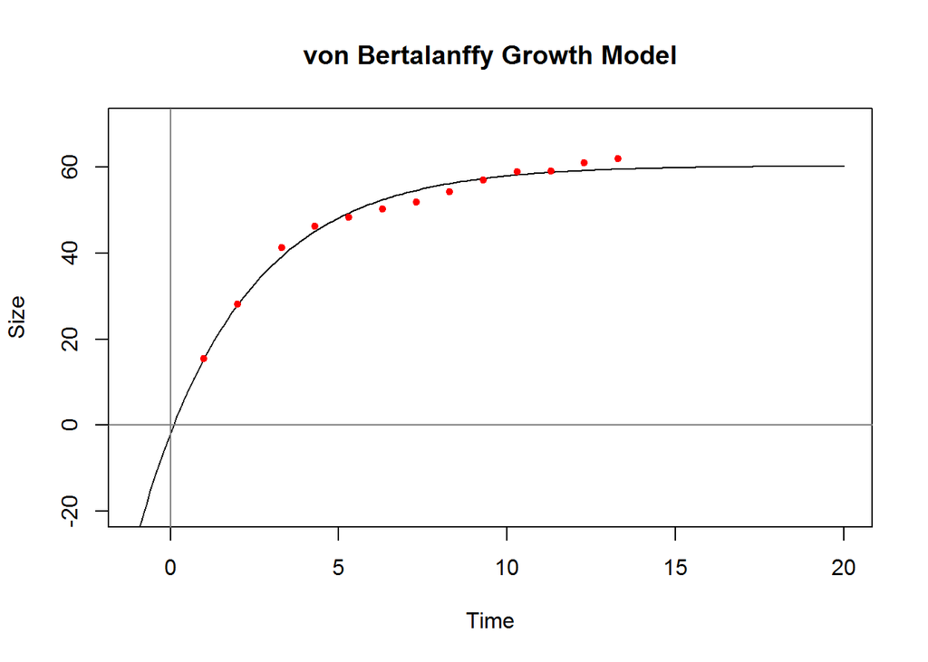

```r
# model predicted values
vecTime=seq(-1, 20, by=0.1)
tmp <- modelVBGF(
    vecTime,
    res$par[1], res$par[2], res$par[3])

# plot predicted values
plot(vecTime, tmp,
     main="von Bertalanffy Growth Model",
     xlab="Time",ylab="Size",
     ylim=c(-20,70),
     type = "l")

# coordinates
abline(v=0,h=0,col="grey50")

# plot the observed data
points(datObs$Time, datObs$Obs, pch=20, col="red")
```

# Bayesian Analysis

we first need to define the ranges of each parameter

Linf should be positive, but should not be too large. Here we will set the Linf in range(1,100)

K is the growth rate and hence should be positive. The size of fish reaches faster to Linf when K is larger. We can see the effect of K from following plot. Here we will set k in range(0.01, 1.0)

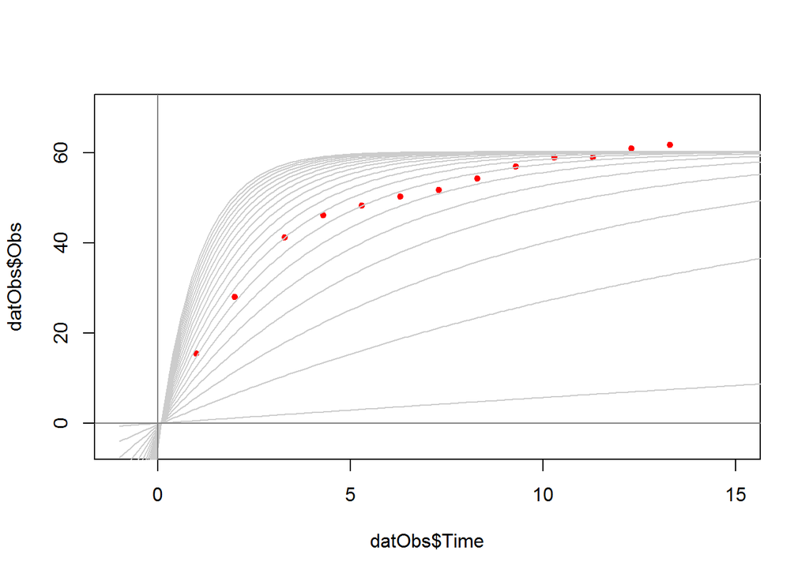

```r
# plot observe data
plot(datObs$Time, datObs$Obs,
     pch=20, col="red",
     xlim=c(-1,15),
     ylim=c(-5, 70))

# model predicted values
vecTime = seq(-1, 20, by=0.1)
K = seq(0.01, 1.0, by=0.05)

# show each model
for (k in K){
    tmp <- modelVBGF(
        vecTime,
        res$par[1], # Linf
        k,          # K
        res$par[3]) # t0
    lines(vecTime, tmp, col="grey80")
} # end func

# coordinates
abline(v=0,h=0,col="grey50")
```

For t0, the value can be negative or positive. However, it must be smaller than the first time point (age = 1). The value is very small compare to Linf and K. Here we assume in fall in the range(-0.5, 0.5)

### Define Prior

choose your prior

```r
# prior with uniform probability generator
LPrior <- function(x){
    dunif(x, min=1,    max=100)
}

KPrior <- function(x){
    dunif(x, min=0.01, max=1.0)
}

TPrior <- function(x){
    dunif(x, min=-0.5, max=0.5)
}
```

ranges of each parameters

```r
LStep <- 5
KStep <- 0.05
TStep <- 0.05

Linf <- seq(1,    100, by=LStep)
K    <- seq(0.01, 1.0, by=KStep)
T0   <- seq(-0.5, 0.5, by=TStep)
```

create all combinations using function expand.grid

```r
matComb <- do.call(
    expand.grid,
    list(Linf, K, T0))
colnames(matComb) <- c("Linf", "K", "T0")
```

### Estimate Posterior: Grid Method

```r
# calculate likelihood for all combinations
mat <- matComb
mat$LL <- apply(mat, 1, function(x){
    res <- getLLDat(datObs, x)$T_LL *
        LPrior(x[1]) *
        KPrior(x[2]) *
        TPrior(x[3])
    return(res)})

# grid method to get probability
mat$Prob <- mat$LL/sum(mat$LL)
```

to show the distribution let’s fix one parameters

```r
dat <- mat %>% filter(T0 < 0.15) %>% filter(T0 > 0.05)
unique(dat$T0) # 0.05
```

```
## [1] 0.05 0.10
```

plot with heatmap (0.1, 0.01 => -1, -2 => 1, 2)

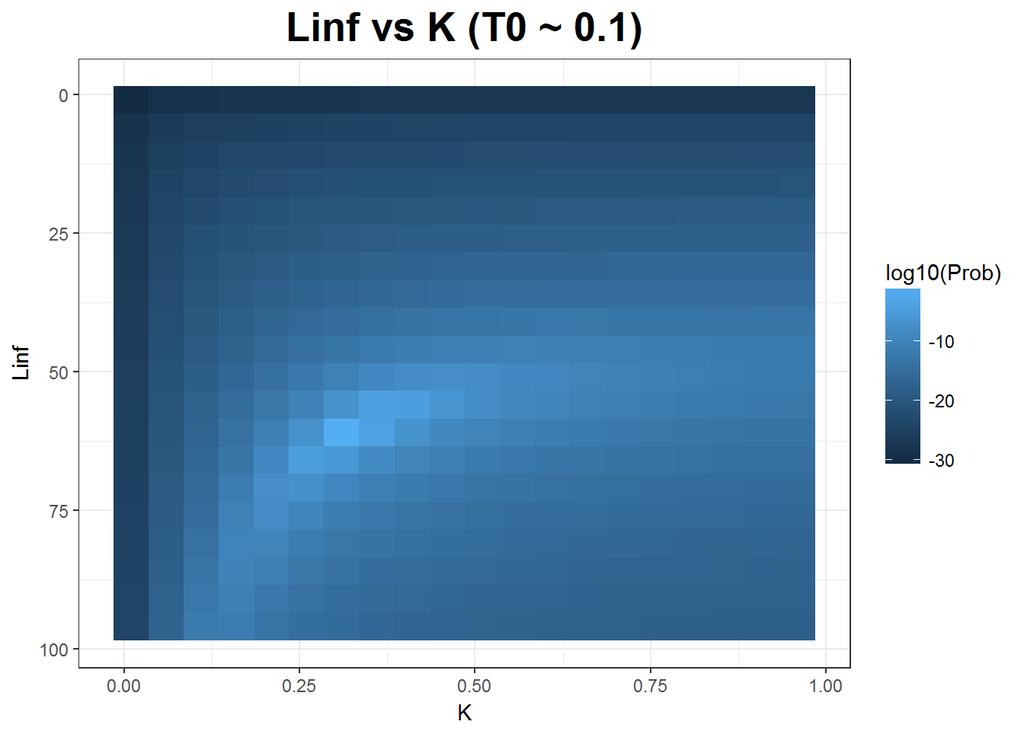

```r
gp <- ggplot(dat, aes(x=K, y=Linf, fill=log10(Prob)))
gp <- gp +
    geom_tile() +
    scale_y_reverse() +
    theme_bw() +
    ggtitle("Linf vs K (T0 ~ 0.1)") +
    theme(plot.title = element_text(
        size  = 20,
        face  = "bold",
        hjust = 0.5))
print(gp)
```

plot with heatmap

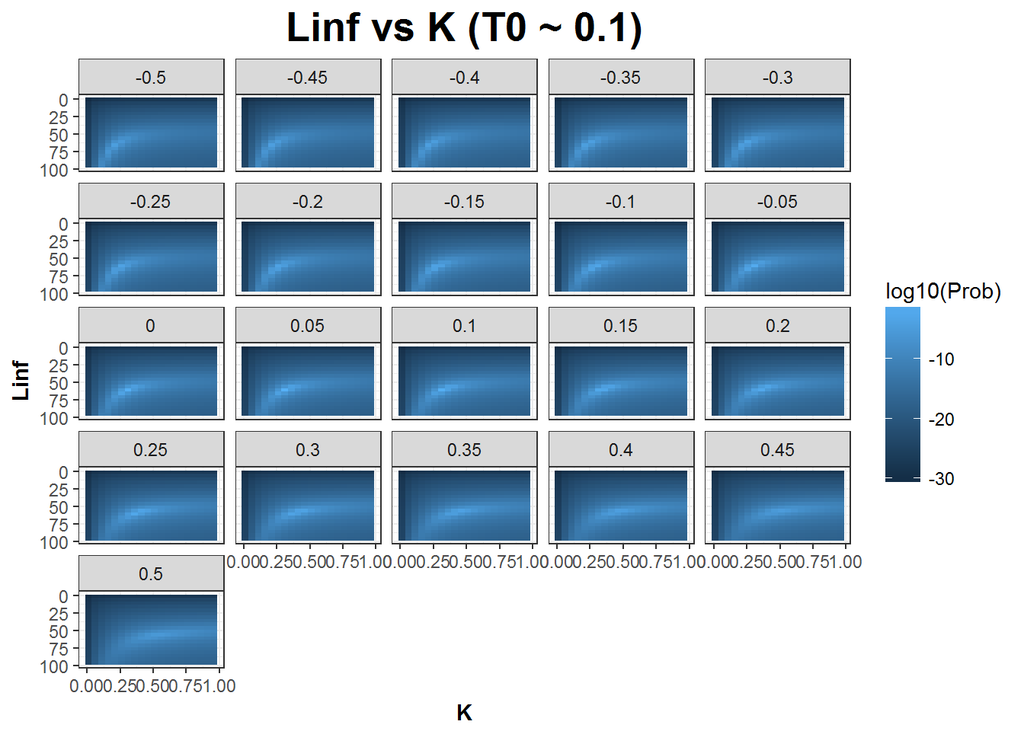

```r
dat <- mat
gp <- ggplot(dat, aes(x=K, y=Linf, fill=log10(Prob)))
gp <- gp +
    geom_tile() +
    scale_y_reverse() +
    theme_bw() +
    ggtitle("Linf vs K (T0 ~ 0.1)") +
    theme(
        plot.title = element_text(
            size  = 20,
            face  = "bold",
            hjust = 0.5),
        axis.title = element_text(
            face="bold")) +
        facet_wrap(~T0, ncol = 5)

print(gp)
```

get marginal

```r
lst <- list()
lst$datL <- mat %>%
    group_by(Linf) %>%
    summarise(Marginal=sum(Prob)) %>%
    rename(Value = Linf) %>%
    mutate(Var = "Linf")
lst$datK <- mat %>%
    group_by(K) %>%
    summarise(Marginal=sum(Prob)) %>%
    rename(Value = K) %>%
    mutate(Var = "K")
lst$datT <- mat %>%
    group_by(T0) %>%
    summarise(Marginal=sum(Prob)) %>%
    rename(Value = T0) %>%
    mutate(Var = "T0")
dat <- do.call("rbind", lst)
```

plot the marginal probabiliry of variables

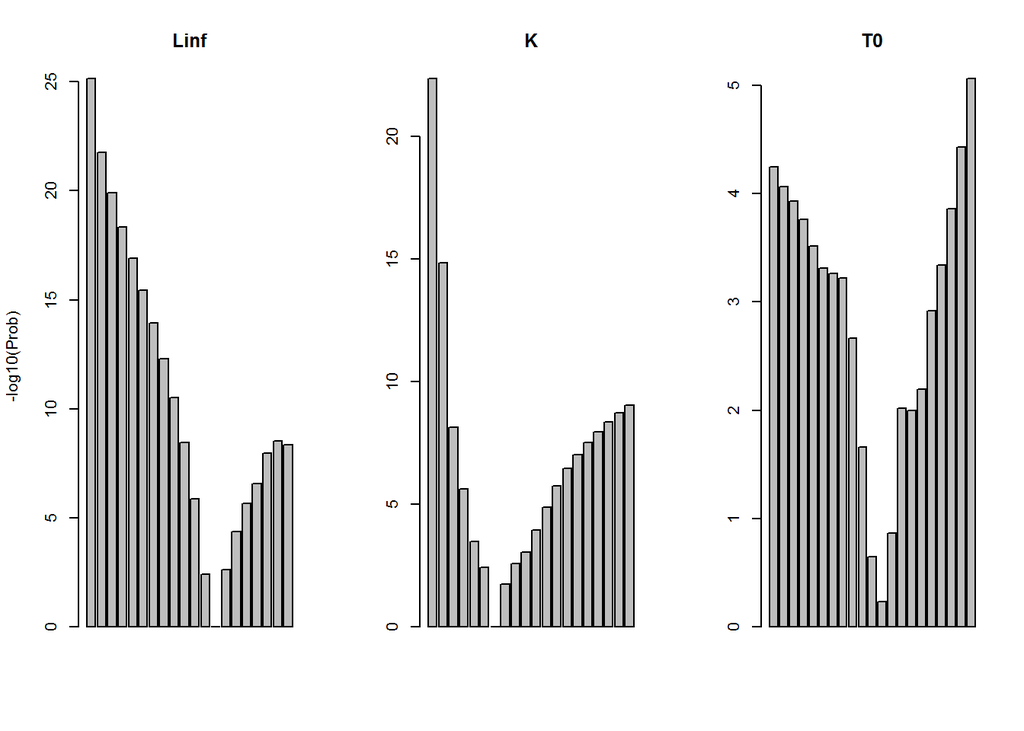

```r
par(mfrow=c(1,3))
barplot(-log10(lst$datL$Marginal),
        main="Linf",
        ylab="-log10(Prob)")
barplot(-log10(lst$datK$Marginal),
        main="K")
barplot(-log10(lst$datT$Marginal),
        main="T0")
```

```r
par(mfrow=c(1,1))
```

### Estimate Posterior: SIR Method

uniform number generator

```r
genL <- function(x){
    runif(x, min=1, max=100)
} # end func

genK <- function(x){
    runif(x, min=0.01, max=1.0)
} # end func

genT <- function(x){
    runif(x, min=-0.5, max=0.5)
} # end func
```

draw numbers

```r
nDraw <- 10000

# column 1,2,3 = L, K, T0
mat <- rbind(genL(nDraw), genK(nDraw), genT(nDraw))

# column 4
# => likelihood of the data with selected parameters
mat <- rbind(
    mat,
    apply(mat, 2, function(x){
        getLLDat(datObs, x)$"T_LL"
    }))

# column 5 U[0,1]
mat <- rbind(mat,runif(nDraw,min=0, max=1))

# assign column names
rownames(mat) <- c(
    "Linf", "K", "T0",
    "LL", "U[0-1]")
```

decide accept or reject

```r
dat <- as.data.frame(t(mat))
dat$isAccepted <- dat$LL/exp(-33.3607)*10^10 > dat$`U[0-1]`
table(dat$isAccepted)
```

```
##
## FALSE  TRUE
##  9052   948
```

plot the result

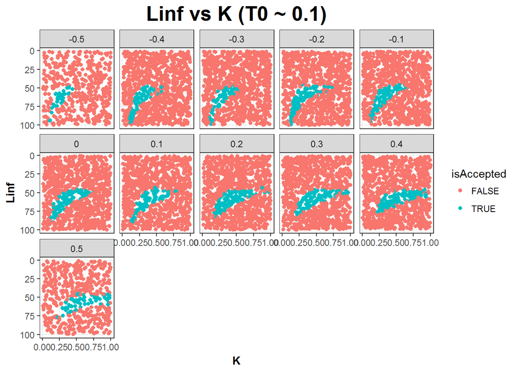

```r
tmp <- dat
tmp$T0 <- round(tmp$T0, 1)

gp <- ggplot(tmp, aes(x=K, y=Linf, color=isAccepted))
gp <- gp +
    geom_point() +
    scale_y_reverse() +
    theme_bw() +
    ggtitle("Linf vs K (T0 ~ 0.1)") +
    theme(
        plot.title = element_text(
            size  = 20,
            face  = "bold",
            hjust = 0.5),
        axis.title = element_text(
            face="bold")) +
        facet_wrap(~T0, ncol = 5)

print(gp)
```

plot the marginal probability of variables

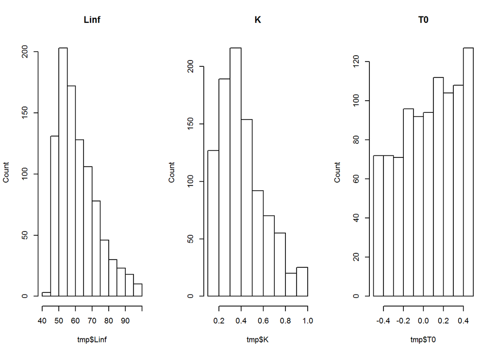

```r
# filter out the rejected points
tmp <- dat %>% filter(isAccepted)

# plot
par(mfrow=c(1,3))
hist(tmp$Linf, main="Linf", ylab="Count")
hist(tmp$K,    main="K",    ylab="Count")
hist(tmp$T0,   main="T0",   ylab="Count")
```

```r
par(mfrow=c(1,1))
```